# Auto1 case study bis

```python
#to handle data
import math
import numpy as np
import pandas as pd

#to plot data
import seaborn as sns
import matplotlib.pyplot as plt

#to build models
from sklearn import model_selection
from sklearn.ensemble import RandomForestRegressor,GradientBoostingRegressor
from sklearn import metrics

#for better display
import warnings
import matplotlib.cbook
warnings.filterwarnings("ignore")
warnings.filterwarnings("ignore",category=matplotlib.cbook.mplDeprecation)
pd.set_option('display.width', 1000)
pd.set_option('display.max_columns', 30)
pd.set_option('display.max_rows', 300)
```

## 1.Import and explore dataset

```python
df=pd.read_csv(r'/Users/pauljacques/Downloads/Auto1-DS-TestData.csv')
df.head(n=20)
```

|  | symboling | normalized-losses | make | fuel-type | aspiration | num-of-doors | body-style | drive-wheels | engine-location | wheel-base | length | width | height | curb-weight | engine-type | num-of-cylinders | engine-size | fuel-system | bore | stroke | compression-ratio | horsepower | peak-rpm | city-mpg | highway-mpg | price |
| --- | --- | --- | --- | --- | --- | --- | --- | --- | --- | --- | --- | --- | --- | --- | --- | --- | --- | --- | --- | --- | --- | --- | --- | --- | --- | --- |
| 0 | 3 | ? | alfa-romero | gas | std | two | convertible | rwd | front | 88.6 | 168.8 | 64.1 | 48.8 | 2548 | dohc | four | 130 | mpfi | 3.47 | 2.68 | 9.0 | 111 | 5000 | 21 | 27 | 13495 |
| 1 | 3 | ? | alfa-romero | gas | std | two | convertible | rwd | front | 88.6 | 168.8 | 64.1 | 48.8 | 2548 | dohc | four | 130 | mpfi | 3.47 | 2.68 | 9.0 | 111 | 5000 | 21 | 27 | 16500 |
| 2 | 1 | ? | alfa-romero | gas | std | two | hatchback | rwd | front | 94.5 | 171.2 | 65.5 | 52.4 | 2823 | ohcv | six | 152 | mpfi | 2.68 | 3.47 | 9.0 | 154 | 5000 | 19 | 26 | 16500 |
| 3 | 2 | 164 | audi | gas | std | four | sedan | fwd | front | 99.8 | 176.6 | 66.2 | 54.3 | 2337 | ohc | four | 109 | mpfi | 3.19 | 3.40 | 10.0 | 102 | 5500 | 24 | 30 | 13950 |
| 4 | 2 | 164 | audi | gas | std | four | sedan | 4wd | front | 99.4 | 176.6 | 66.4 | 54.3 | 2824 | ohc | five | 136 | mpfi | 3.19 | 3.40 | 8.0 | 115 | 5500 | 18 | 22 | 17450 |
| 5 | 2 | ? | audi | gas | std | two | sedan | fwd | front | 99.8 | 177.3 | 66.3 | 53.1 | 2507 | ohc | five | 136 | mpfi | 3.19 | 3.40 | 8.5 | 110 | 5500 | 19 | 25 | 15250 |
| 6 | 1 | 158 | audi | gas | std | four | sedan | fwd | front | 105.8 | 192.7 | 71.4 | 55.7 | 2844 | ohc | five | 136 | mpfi | 3.19 | 3.40 | 8.5 | 110 | 5500 | 19 | 25 | 17710 |
| 7 | 1 | ? | audi | gas | std | four | wagon | fwd | front | 105.8 | 192.7 | 71.4 | 55.7 | 2954 | ohc | five | 136 | mpfi | 3.19 | 3.40 | 8.5 | 110 | 5500 | 19 | 25 | 18920 |
| 8 | 1 | 158 | audi | gas | turbo | four | sedan | fwd | front | 105.8 | 192.7 | 71.4 | 55.9 | 3086 | ohc | five | 131 | mpfi | 3.13 | 3.40 | 8.3 | 140 | 5500 | 17 | 20 | 23875 |
| 9 | 0 | ? | audi | gas | turbo | two | hatchback | 4wd | front | 99.5 | 178.2 | 67.9 | 52.0 | 3053 | ohc | five | 131 | mpfi | 3.13 | 3.40 | 7.0 | 160 | 5500 | 16 | 22 | ? |
| 10 | 2 | 192 | bmw | gas | std | two | sedan | rwd | front | 101.2 | 176.8 | 64.8 | 54.3 | 2395 | ohc | four | 108 | mpfi | 3.50 | 2.80 | 8.8 | 101 | 5800 | 23 | 29 | 16430 |
| 11 | 0 | 192 | bmw | gas | std | four | sedan | rwd | front | 101.2 | 176.8 | 64.8 | 54.3 | 2395 | ohc | four | 108 | mpfi | 3.50 | 2.80 | 8.8 | 101 | 5800 | 23 | 29 | 16925 |
| 12 | 0 | 188 | bmw | gas | std | two | sedan | rwd | front | 101.2 | 176.8 | 64.8 | 54.3 | 2710 | ohc | six | 164 | mpfi | 3.31 | 3.19 | 9.0 | 121 | 4250 | 21 | 28 | 20970 |
| 13 | 0 | 188 | bmw | gas | std | four | sedan | rwd | front | 101.2 | 176.8 | 64.8 | 54.3 | 2765 | ohc | six | 164 | mpfi | 3.31 | 3.19 | 9.0 | 121 | 4250 | 21 | 28 | 21105 |
| 14 | 1 | ? | bmw | gas | std | four | sedan | rwd | front | 103.5 | 189.0 | 66.9 | 55.7 | 3055 | ohc | six | 164 | mpfi | 3.31 | 3.19 | 9.0 | 121 | 4250 | 20 | 25 | 24565 |
| 15 | 0 | ? | bmw | gas | std | four | sedan | rwd | front | 103.5 | 189.0 | 66.9 | 55.7 | 3230 | ohc | six | 209 | mpfi | 3.62 | 3.39 | 8.0 | 182 | 5400 | 16 | 22 | 30760 |
| 16 | 0 | ? | bmw | gas | std | two | sedan | rwd | front | 103.5 | 193.8 | 67.9 | 53.7 | 3380 | ohc | six | 209 | mpfi | 3.62 | 3.39 | 8.0 | 182 | 5400 | 16 | 22 | 41315 |
| 17 | 0 | ? | bmw | gas | std | four | sedan | rwd | front | 110.0 | 197.0 | 70.9 | 56.3 | 3505 | ohc | six | 209 | mpfi | 3.62 | 3.39 | 8.0 | 182 | 5400 | 15 | 20 | 36880 |
| 18 | 2 | 121 | chevrolet | gas | std | two | hatchback | fwd | front | 88.4 | 141.1 | 60.3 | 53.2 | 1488 | l | three | 61 | 2bbl | 2.91 | 3.03 | 9.5 | 48 | 5100 | 47 | 53 | 5151 |
| 19 | 1 | 98 | chevrolet | gas | std | two | hatchback | fwd | front | 94.5 | 155.9 | 63.6 | 52.0 | 1874 | ohc | four | 90 | 2bbl | 3.03 | 3.11 | 9.6 | 70 | 5400 | 38 | 43 | 6295 |

```python
df.info()
```

```
<class 'pandas.core.frame.DataFrame'>
RangeIndex: 205 entries, 0 to 204
Data columns (total 26 columns):
symboling            205 non-null int64
normalized-losses    205 non-null object
make                 205 non-null object
fuel-type            205 non-null object
aspiration           205 non-null object
num-of-doors         205 non-null object
body-style           205 non-null object
drive-wheels         205 non-null object
engine-location      205 non-null object
wheel-base           205 non-null float64
length               205 non-null float64
width                205 non-null float64
height               205 non-null float64
curb-weight          205 non-null int64
engine-type          205 non-null object
num-of-cylinders     205 non-null object
engine-size          205 non-null int64
fuel-system          205 non-null object
bore                 205 non-null object
stroke               205 non-null object
compression-ratio    205 non-null float64
horsepower           205 non-null object
peak-rpm             205 non-null object
city-mpg             205 non-null int64
highway-mpg          205 non-null int64
price                205 non-null object
dtypes: float64(5), int64(5), object(16)
memory usage: 41.7+ KB
```

### 1.1.Explore target variable 'price'

```python
df.price=pd.to_numeric(df.price,'coerce')
df=df[pd.notnull(df['price'])]
```

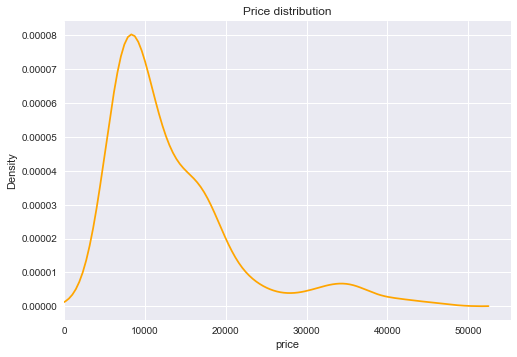

```python
sns.distplot(df.price,hist=False,color="orange")
plt.title('Price distribution')
plt.ylabel('Density')
plt.xlim(xmin=-10)#min(df['price']))
plt.show()
```

### 1.2.Explore explanatory variables

#### 1.2.1.Categorical variables

```python
def category_type(df):
    df['symboling']=df['symboling'].astype('category')
    df['fuel-type']=df['fuel-type'].astype('category')
    df['make']=df['make'].astype('category')
    df['aspiration']=df['aspiration'].astype('category')
    df['num-of-doors']=df['num-of-doors'].astype('category')
    df['body-style']=df['body-style'].astype('category')
    df['drive-wheels']=df['drive-wheels'].astype('category')
    df['engine-location']=df['engine-location'].astype('category')
    df['engine-type']=df['engine-type'].astype('category')
    df['num-of-cylinders']=df['num-of-cylinders'].astype('category')
    df['fuel-system']=df['fuel-system'].astype('category')
    return(df)

df=category_type(df)
```

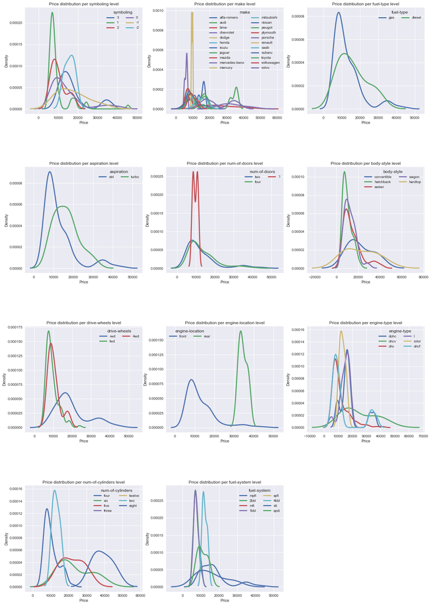

```python
cat_var={}
categories= list((df.select_dtypes(include=['category'])))

for x in categories:
    cat_var[x]=df[x].unique()

fig, ax = plt.subplots(sharex=True,nrows=4, ncols=3,figsize=(20,30))
fig.subplots_adjust(hspace=.5)
for idx, key in enumerate(cat_var):
    for value in cat_var[key]:
        subset= df[df[key] == value]
        ax_coord = plt.subplot(4, 3, idx+1)
        sns.distplot(subset['price'], hist = False, ax= ax_coord, kde = True,kde_kws = {'linewidth': 3},label = value)
    ax_coord.legend(fontsize=10,title = key,ncol=2)
    ax_coord.set_title('Price distribution per %s level'% key)
    ax_coord.set_xlabel('Price')
    ax_coord.set_ylabel('Density')
    fig.delaxes(plt.subplot(4,3,12))
plt.show()
```

These plots allow us to understand the impact of each variable on the price of a car. Many conclusions can be driven from just looking at those graphs, for instance:

- The price distribution is different for each level of the symboling variable, which leads us to think there is a correlation, or an impact, of the symboling variable on the price of the car.
- On the contrary, the price distribution is similar no matter if a car has 2 or 4 doors, thus leaving us thinking that this won't be a good explanatory variable in our model.

#### 1.2.2.Continuous variables

##### 1.2.2.1.Visual exploration

```python
def numeric_type(df):
    df['normalized-losses']=pd.to_numeric(df['normalized-losses'],'coerce')
    df['wheel-base']=pd.to_numeric(df['wheel-base'],'coerce')
    df['length']=pd.to_numeric(df['length'],'coerce')
    df['width']=pd.to_numeric(df['width'],'coerce')
    df['height']=pd.to_numeric(df['height'],'coerce')
    df['curb-weight']=pd.to_numeric(df['curb-weight'],'coerce')
    df['engine-size']=pd.to_numeric(df['engine-size'],'coerce')
    df['bore']=pd.to_numeric(df['bore'],'coerce')
    df['stroke']=pd.to_numeric(df['stroke'],'coerce')
    df['compression-ratio']=pd.to_numeric(df['compression-ratio'],'coerce')
    df['horsepower']=pd.to_numeric(df['horsepower'],'coerce')
    df['peak-rpm']=pd.to_numeric(df['peak-rpm'],'coerce')
    df['city-mpg']=pd.to_numeric(df['city-mpg'],'coerce')
    df['highway-mpg']=pd.to_numeric(df['highway-mpg'],'coerce')
    return(df)

df=numeric_type(df)
```

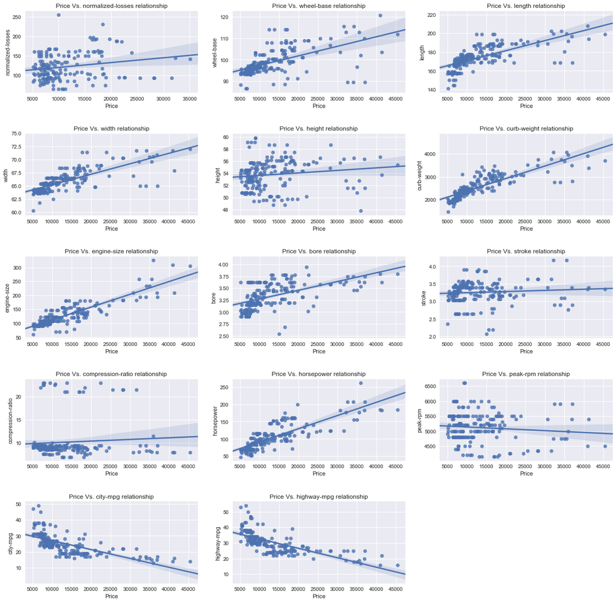

```python
cont_var=list(df.select_dtypes(include=['int','float']))
#['normalized-losses','wheel-base','length','width','height','curb-weight','engine-size','bore','stroke','compression-ratio','horsepower','peak-rpm','city-mpg','highway-mpg']

fig, ax = plt.subplots(nrows=5, ncols=3,figsize=(20,20))
fig.subplots_adjust(hspace=.5)
for idx, var in enumerate(cont_var):
    ax_coord = plt.subplot(5, 3, idx+1)
    sns.regplot(x="price", y=var, data=df)
    ax_coord.set_title('Price Vs. %s relationship'% var)
    ax_coord.set_xlabel('Price')
    ax_coord.set_ylabel(var)
    fig.delaxes(plt.subplot(5,3,15))
plt.show()
```

In the predecessing graph we see the relationship the price has with other continuous variables.

- We see some linear relationship with:
  - curb-weight, engine-size, horsepower, city-mpg and highway-mpg
  - tends to make sense from a business perspective as you would assume the bigger and/or the more powerfull a car is the more expensive it is. There also could be a strong correlation between city-mpg and highway-mpg.
- I would assume a logarithmic relationship with the length and width of car and its price. This could also be explained from a business perspective since a majority of car fall within the same length range, but when they are longer they are more expensive (eg: limo)
- Other variables such as stroke or compression-ratio have less obvious relationships. Only a correlation testing would confirm the assumption.

##### 1.2.2.2.Correlation analysis

```python
df_cont_var=df[cont_var]
```

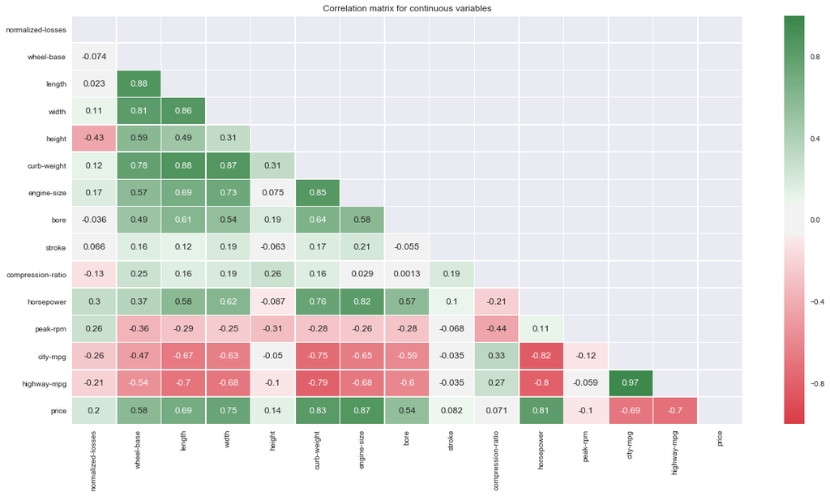

```python
upper_triangle = np.zeros_like(df_cont_var.corr(), dtype = np.bool)
upper_triangle[np.triu_indices_from(upper_triangle)] = True

plt.figure(figsize=(20,10))
sns.heatmap(df_cont_var.corr(),mask=upper_triangle,annot=True,linewidths=0.5,cmap=sns.diverging_palette(10, 133,sep=20, as_cmap=True))
plt.xticks(rotation=90)
plt.title('Correlation matrix for continuous variables')
plt.show()
```

# 2.Feature engineering

## 2.1.Convert categorical variables to dummies

```python
df_dum=df.copy()

def feature_keep(df_dum):
    df_dum=pd.get_dummies(df_dum,prefix=categories,columns=categories)
    return (df_dum)

df_dum=feature_keep(df_dum)
df_dum.info()
```

```
<class 'pandas.core.frame.DataFrame'>
Int64Index: 201 entries, 0 to 204
Data columns (total 81 columns):
normalized-losses          164 non-null float64
wheel-base                 201 non-null float64
length                     201 non-null float64
width                      201 non-null float64
height                     201 non-null float64
curb-weight                201 non-null int64
engine-size                201 non-null int64
bore                       197 non-null float64
stroke                     197 non-null float64
compression-ratio          201 non-null float64
horsepower                 199 non-null float64
peak-rpm                   199 non-null float64
city-mpg                   201 non-null int64
highway-mpg                201 non-null int64
price                      201 non-null float64
symboling_-2               201 non-null uint8
symboling_-1               201 non-null uint8
symboling_0                201 non-null uint8
symboling_1                201 non-null uint8
symboling_2                201 non-null uint8
symboling_3                201 non-null uint8
make_alfa-romero           201 non-null uint8
make_audi                  201 non-null uint8
make_bmw                   201 non-null uint8
make_chevrolet             201 non-null uint8
make_dodge                 201 non-null uint8
make_honda                 201 non-null uint8
make_isuzu                 201 non-null uint8
make_jaguar                201 non-null uint8
make_mazda                 201 non-null uint8
make_mercedes-benz         201 non-null uint8
make_mercury               201 non-null uint8
make_mitsubishi            201 non-null uint8
make_nissan                201 non-null uint8
make_peugot                201 non-null uint8
make_plymouth              201 non-null uint8
make_porsche               201 non-null uint8
```

[output cut: 31 more lines]

```
num-of-cylinders_four      201 non-null uint8
num-of-cylinders_six       201 non-null uint8
num-of-cylinders_three     201 non-null uint8
num-of-cylinders_twelve    201 non-null uint8
num-of-cylinders_two       201 non-null uint8
fuel-system_1bbl           201 non-null uint8
fuel-system_2bbl           201 non-null uint8
fuel-system_4bbl           201 non-null uint8
fuel-system_idi            201 non-null uint8
fuel-system_mfi            201 non-null uint8
fuel-system_mpfi           201 non-null uint8
fuel-system_spdi           201 non-null uint8
fuel-system_spfi           201 non-null uint8
dtypes: float64(11), int64(4), uint8(66)
memory usage: 38.1 KB
```

```python
features=list(df_dum.columns)
features.remove('price')
```

# 3.Building the models

### 3.1.Ensemble of decision trees

```python
df_dum=df_dum.dropna()
```

```python
df_dum.info()
```

```
<class 'pandas.core.frame.DataFrame'>
Int64Index: 160 entries, 3 to 204
Data columns (total 81 columns):
normalized-losses          160 non-null float64
wheel-base                 160 non-null float64
length                     160 non-null float64
width                      160 non-null float64
height                     160 non-null float64
curb-weight                160 non-null int64
engine-size                160 non-null int64
bore                       160 non-null float64
stroke                     160 non-null float64
compression-ratio          160 non-null float64
horsepower                 160 non-null float64
peak-rpm                   160 non-null float64
city-mpg                   160 non-null int64
highway-mpg                160 non-null int64
price                      160 non-null float64
symboling_-2               160 non-null uint8
symboling_-1               160 non-null uint8
symboling_0                160 non-null uint8
symboling_1                160 non-null uint8
symboling_2                160 non-null uint8
symboling_3                160 non-null uint8
make_alfa-romero           160 non-null uint8
make_audi                  160 non-null uint8
make_bmw                   160 non-null uint8
make_chevrolet             160 non-null uint8
make_dodge                 160 non-null uint8
make_honda                 160 non-null uint8
make_isuzu                 160 non-null uint8
make_jaguar                160 non-null uint8
make_mazda                 160 non-null uint8
make_mercedes-benz         160 non-null uint8
make_mercury               160 non-null uint8
make_mitsubishi            160 non-null uint8
make_nissan                160 non-null uint8
make_peugot                160 non-null uint8
make_plymouth              160 non-null uint8
make_porsche               160 non-null uint8
```

[output cut: 31 more lines]

```
num-of-cylinders_four      160 non-null uint8
num-of-cylinders_six       160 non-null uint8
num-of-cylinders_three     160 non-null uint8
num-of-cylinders_twelve    160 non-null uint8
num-of-cylinders_two       160 non-null uint8
fuel-system_1bbl           160 non-null uint8
fuel-system_2bbl           160 non-null uint8
fuel-system_4bbl           160 non-null uint8
fuel-system_idi            160 non-null uint8
fuel-system_mfi            160 non-null uint8
fuel-system_mpfi           160 non-null uint8
fuel-system_spdi           160 non-null uint8
fuel-system_spfi           160 non-null uint8
dtypes: float64(11), int64(4), uint8(66)
memory usage: 30.3 KB
```

```python
rf=RandomForestRegressor(n_estimators=500,
                             criterion='mse')

gb=GradientBoostingRegressor(n_estimators=500,
                             criterion='mse')

x_=np.asarray(df_dum[features])
y_=np.asarray(df_dum['price'])
```

### 3.2.Evaluation metrics

```python
mse_rf=[]
rmse_rf=[]
score_rf=[]
mse_gb=[]
rmse_gb=[]
score_gb=[]

for i in range (10):
    X_train, X_test, y_train, y_test = model_selection.train_test_split(x_, y_, test_size=0.1)
    fitted_rf=rf.fit(X_train, y_train)
    fitted_gb=gb.fit(X_train, y_train)
    mse_rf.append(metrics.mean_squared_error(y_test,fitted_rf.predict(X_test)))
    rmse_rf.append(math.sqrt(metrics.mean_squared_error(y_test,fitted_rf.predict(X_test))))
    score_rf.append(rf.score(X_train, y_train))
    mse_gb.append(metrics.mean_squared_error(y_test,fitted_gb.predict(X_test)))
    rmse_gb.append(math.sqrt(metrics.mean_squared_error(y_test,fitted_gb.predict(X_test))))
    score_gb.append(gb.score(X_train, y_train))
```

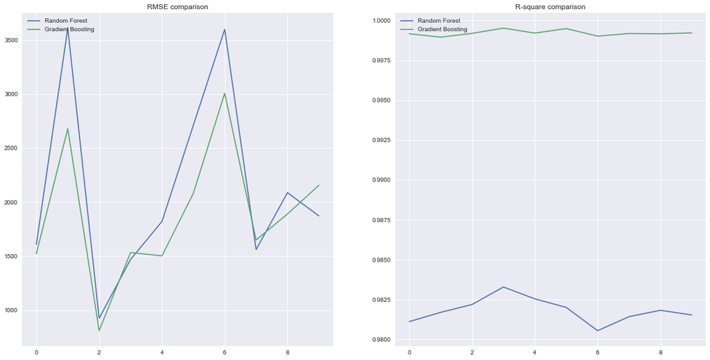

```python
f, (ax1, ax2) = plt.subplots(1, 2,figsize=(20,10))
ax1.plot(rmse_rf,label='Random Forest')
ax1.plot(rmse_gb,label='Gradient Boosting')
ax2.plot(score_rf,label='Random Forest')
ax2.plot(score_gb,label='Gradient Boosting')
ax1.legend(loc='upper left')
ax2.legend(loc='upper left')
ax1.set_title('RMSE comparison')
ax2.set_title('R-square comparison')
plt.show()
```

### 3.3.Model without 'normalized-losses'

We have seen earlier that 'normalized-losses' has a lot of NAs. Removing that variable would allow to run the model on more observations.

We can also assume that this variable is not always available, hence the need of creating a model without it.

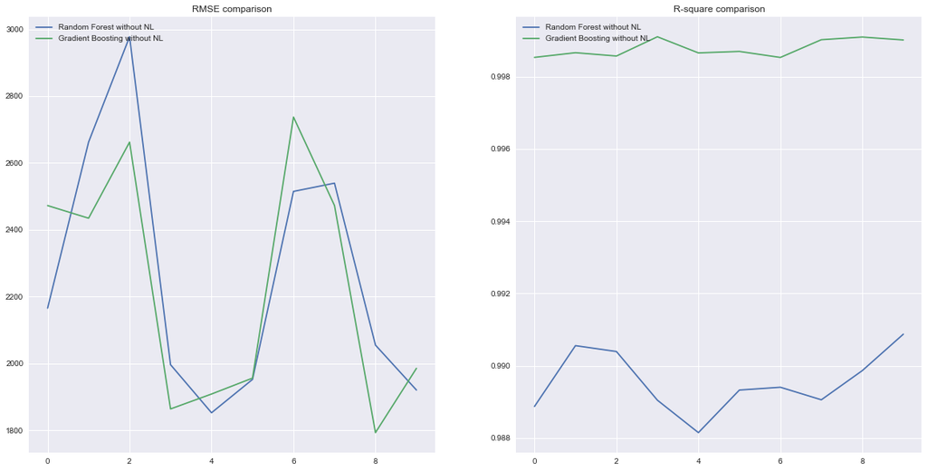

```python
#new dataset without variable
df_dum_bis=df.copy()
df_dum_bis=feature_keep(df_dum_bis)
df_dum_bis=df_dum_bis.drop('normalized-losses',axis=1)
df_dum_bis=df_dum_bis.dropna()

#new set of features
features_bis=list(df_dum_bis.columns)
features_bis.remove('price')
x_bis=np.asarray(df_dum_bis[features_bis])
y_bis=np.asarray(df_dum_bis['price'])

#new metrics
mse_rf_bis=[]
rmse_rf_bis=[]
score_rf_bis=[]
mse_gb_bis=[]
rmse_gb_bis=[]
score_gb_bis=[]

for i in range (10):
    X_train_bis, X_test_bis, y_train_bis, y_test_bis = model_selection.train_test_split(x_bis, y_bis, test_size=0.1)
    fitted_rf_bis=rf.fit(X_train_bis, y_train_bis)
    fitted_gb_bis=gb.fit(X_train_bis, y_train_bis)
    mse_rf_bis.append(metrics.mean_squared_error(y_test_bis,fitted_rf_bis.predict(X_test_bis)))
    rmse_rf_bis.append(math.sqrt(metrics.mean_squared_error(y_test_bis,fitted_rf_bis.predict(X_test_bis))))
    score_rf_bis.append(rf.score(X_train_bis, y_train_bis))
    mse_gb_bis.append(metrics.mean_squared_error(y_test_bis,fitted_gb_bis.predict(X_test_bis)))
    rmse_gb_bis.append(math.sqrt(metrics.mean_squared_error(y_test_bis,fitted_gb_bis.predict(X_test_bis))))
    score_gb_bis.append(gb.score(X_train_bis, y_train_bis))

#new metrics plots
f, (ax1, ax2) = plt.subplots(1, 2,figsize=(20,10))
ax1.plot(rmse_rf_bis,label='Random Forest without NL')
ax1.plot(rmse_gb_bis,label='Gradient Boosting without NL')
ax2.plot(score_rf_bis,label='Random Forest without NL')
ax2.plot(score_gb_bis,label='Gradient Boosting without NL')
ax1.legend(loc='upper left')
ax2.legend(loc='upper left')
ax1.set_title('RMSE comparison')
ax2.set_title('R-square comparison')
plt.show()
```

The models do not seem to perform differently with or without the removed variable. The small differences in the metrics are explained by the train and test split.

### 3.4.Feature importance

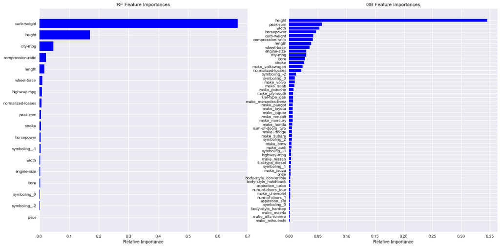

```python
features = list(df_dum.columns)
importances_rf = rf.feature_importances_[rf.feature_importances_>0.001]
indices_rf = np.argsort(importances_rf)

importances_gb = gb.feature_importances_[gb.feature_importances_>0.001]
indices_gb = np.argsort(importances_gb)

f, (ax1, ax2) = plt.subplots(1, 2,figsize=(20,10))
ax1.set_title('RF Feature Importances')
ax1.barh(range(len(indices_rf)), importances_rf[indices_rf], color='b', align='center')
ax1.set_yticks(range(len(indices_rf)))
ax1.set_yticklabels([features[i] for i in indices_rf])
ax1.set_xlabel('Relative Importance')
ax2.set_title('GB Feature Importances')
ax2.barh(range(len(indices_gb)), importances_gb[indices_gb], color='b', align='center')
ax2.set_yticks(range(len(indices_gb)))
ax2.set_yticklabels([features[i] for i in indices_gb])
ax2.set_xlabel('Relative Importance')
plt.show()
```